# Final Project

Author

Affiliation

Sierra Wei

University of Pennsylvania

Published

May 10, 2024

## 1. Introduction

Mormons, Jehovah’s Witnesses, and Adventists form a distinctive group in Latin America. These religions are all relatively recent offshoots of Christianity that require a high degree of devotion from its followers. Missionary efforts from these religions have successfully converted millions in Latin America. I am interested in whether Fringe Christians in Latin America are more favorable to the US as a result of this. This paper aims to to study Fringe Christians in comparison to the dominant religion, Catholicism, as well as Evangelical Christianity, another quickly growing Christian sect.

In the US, members of these Fringe Christian religions hold different views from traditional mainstream Christian beliefs. Mormons overwhelmingly vote Republican, but Utah (over 60% Mormon) residents support issues like gun reform, the ERA, and increased sexual education (Larsen 2022). Adventists are one of the most devout religious groups in the US but have varied political beliefs (Lipka 2015). Jehovah’s Witnesses developed within the Adventist movement in the 19th century in the US (2024). They tend to be conservative, but remain politically inactive (Lipka 2016). Together, these three religions will be referred to as Fringe Christian religions.

In Latin America, rates of religious participation have declined in the past few decades, also decreasing the influence of religious institutions. With the rise of Protestantism (which includes Evangelicalism), atheism, and fringe American Christian religions (Seventh Day Adventists, Jehovah’s Witnesses, and Mormonism) from the mid 1800s onward, the long-dominant Catholic Church found itself struggling for continued influence. After several failed strategies to renew Catholic fervor, the Catholic Church began a new effort to sever ties with the political elite and refocus on helping the rural and urban poor (Gill 1998). In the 1960s and 1980s in some Latin American countries like Brazil, Chile, and Argentina, the Catholic Church stood against dictatorships and promoted democracy (Jelen and Wilcox 2002). Today, Latin America’s religious landscape is still 69% Catholic, however, this is less Catholic than in previous decades. On average, Catholics are also less devout than Protestants (Lipka 2014).

Mormonism surged starting in the latter half of the 20th century in Latin America. The Mormon population grew from around 700,000 in 1980 to 4.5 million in 2004 (making up over a third of the worldwide Mormon population at the time). One recent convert remarked: “Mormonism is an American form of Christianity in that it represents all of the American values of self-discipline and self-reliance” (Ayala 2004). Most members are concentrated in Argentina, Brazil, Chile, Ecuador, Guatemala, Mexico, and Peru. However, within these countries, Mormon membership is unevenly distributed due to political, social, and cultural factors that affect the populace’s engagement with the religion. Mormonism is also concentrated in urban areas (similar to in the US) and is described as having a “middle class” character to its structure and values. Most Mormon leaders are a mix of Latin Americans and non-Latin Americans and come from the middle or upper class, since becoming a leader requires intense time and education commitments (Knowlton 1996).

According to reports from the Seventh-Day Adventist global organization, there are over 2 million Seventh Day Adventists in Argentina, Bolivia, Brazil, Chile, Ecuador, Paraguay, Peru, and Uruguay, making up the South American Division. Throughout much of the 20th century, Adventists in these countries were led by North Americans. From the mid 1970s onward, the leadership has been made up of Brazilians (Holdorf 2021). The Inter-American Division of the Seventh Day Adventists includes Mexico, Belize, Colombia, Dominican Republic, El Salvador, French Guiana, Honduras, Nicaragua, Panama, Suriname, Venezuela, and other islands in the Caribbean. As of 2020, this division reported over 3.8 million members. Out of the 13 global Seventh Day Adventist divisions, the Inter-American Division is one of the largest and fastest growing divisions (Phillips and Leito 2020).

The Jehovah’s Witnesses website reports over 2.5 million members in Latin American countries (2023). Jehovah’s Witnesses are instructed to be involved with the secular world as little as possible because the world will soon become increasingly evil. Members are encouraged to convert as many people as possible to show religious devotion. Typically, equals convert equals, meaning potential converts are faced with missionaries of a similar social status. This approach has led to large-scale success in South America (Alston and Aguirre 1979).

## 2. Theory and Hypotheses

#### Hypothesis

Mormons, Jehovah’s Witnesses, and Adventists will think more highly of the US than the mainstream Christian population.

Because these Fringe Christian religions all originated in the US and many people in these religions in Latin America will be converts, I hypothesize they will have more positive exposure to Americans and US beliefs. This is because people in these religions will be more likely to have had exposure to Americans and American values through missionaries and religious messaging. They may associate positive feelings regarding their religion with positive feelings towards America, where such religions originated. Influential members of these religions are also Americans, which may increase this effect. Therefore, people in Fringe Christian religions will be more favorable towards the US, compared to Catholics and Evangelicals.

In studies of Pentecostal converts in Guatemala, researchers saw that “pentecostalized religious beliefs and charismatic experiences” across religious affiliations in Guatemala appear to be the most important religious factors driving political attitudes and actions (Steigenga and Cleary 2007). That is to say that Pentecostalism had a significant effect on individual’s experiences and actions. Similarly, I expect that Fringe Christian religious attitudes will affect many aspects of an individual’s life, such as their opinions towards the US.

## 3. Research Design

My research utilizes the Latinobarómetro from 2023. The unit of analysis is respondent and the sample is made up of at least 1000 respondents from 17 surveyed countries. This dataset is not representative of the religious make-up by country and the Evangelical population in certain countries is skewed.

In my analysis, I have only included individuals who identified as religious in order perform a comparison across religious individuals. I will be using the religion variable, religious devotion variable, socioeconomic status variable, favorability towards the US variable, education variable, and nationality variable. To test my hypothesis, I will use the following equation:

$$Favorability\_towards\_USi = \alpha + \beta_1 Religion_{i} + \epsilon_i$$

I also consider factors such as religious devotion, education, socioeconomic status, and nationality that might explain the results of the initial regression model.

To do this, I will use the following equations:

$$Favorability\_towards\_USi = \alpha + \beta_1 Religion_{i} + \beta_2 Devotion_{i} + \beta_3 (Religion_{i} * Devotion_{i}) + \epsilon_i$$

$$Favorability\_towards\_USi = \alpha + \beta_1 Religion_{i} + \beta_2 Socioeconomic Status_{i} + \beta_3 (Religion_{i} * Socioeconomic Status_{i}) + \epsilon_i$$

$$Favorability\_towards\_USi = \alpha + \beta_1 Religion_{i} + \beta_2 Education_{i} + \beta_3 (Religion_{i} * Education_{i}) + \epsilon_i$$
$$Favorability\_towards\_USi = \alpha + \beta_1 Religion_{i} + \beta_2 Nationality_{i} + \beta_3 (Religion_{i} * Nationality_{i})+ \epsilon_i$$

#### Religion Variable

Over half of respondents identified as Catholic in the religion question. The second most popular response was Evangelical. I have removed participants who responded as Atheist, Agnostic, or None in my analysis in order to solely focus on those who identify as religious in some way. I also created a Fringe Christian religion variable with Adventists, Jehovah’s Witnesses, Mormons.

| Religion | Count | Percent |
| --- | --- | --- |
| adventist | 89 | 0.5% |
| african cult/umbanda | 67 | 0.4% |
| agnostic | 46 | 0.2% |
| atheist | 177 | 0.9% |
| believer, no church | 268 | 1.4% |
| catholic | 10,354 | 54.8% |
| evangelical | 4,478 | 23.7% |
| evangelical baptism | 62 | 0.3% |
| evangelical methodist | 108 | 0.6% |
| evangelical pentecostal | 86 | 0.5% |
| jewish | 4 | 0.0% |
| jv | 105 | 0.6% |
| mormon | 41 | 0.2% |
| none | 2,843 | 15.0% |
| other | 139 | 0.7% |
| protestant | 38 | 0.2% |
| Total | 18,905 | 100.0% |

#### Religious Devotion Variable

Across religions, most Latin Americans fall into either the Not very devout or Devout categories, which are the middle two values for level of devotion. The mean level of devotion falls squarely between “Not very devout” and “Devout.”

| Statistic | Value |
| --- | --- |
| Mean | 0.49 |
| Standard Deviation | 0.30 |

| Level of Devotion | Count | Percent |
| --- | --- | --- |
| 0.00 (Not devout at all) | 2,084 | 13.7% |
| 0.33 (Not very devout) | 5,678 | 37.4% |
| 0.67 (Devout) | 5,466 | 36.0% |
| 1.00 (Very devout) | 1,959 | 12.9% |
| Total | 15,187 | 100.0% |

#### Socioeconomic Status

In my survey, Catholics, Evangelicals, and Fringe Christians came from a similar socioeconomic status. The average individual in all groups was described as in between “Average” and “Good”. In Chile and Argentina, researchers found that lower socioeconomic status accounted for lower levels of democratic attitudes (Patterson 2004). My analysis will attempt to determine if socioeconomic status significant affects favorability towards the US.

| Statistic | Value |
| --- | --- |
| Mean | 0.64 |
| Standard Deviation | 0.22 |

| Socioeconomic Status | Count | Percent |
| --- | --- | --- |
| 0.00 (Very bad) | 202 | 1.3% |
| 0.25 (Bad) | 1,316 | 8.2% |
| 0.50 (Average) | 6,078 | 38.0% |
| 0.75 (Good) | 6,370 | 39.8% |
| 1.00 (Very good) | 2,034 | 12.7% |
| Total | 16,000 | 100.0% |

#### Opinions Towards the US Variable

When Latin Americans were asked about their opinions towards the US, 8.3% answered “Very unfavorable,” 12.4% responded “Unfavorable,” 46.8% of religious respondents answered “Favorable,” and 25.9% responded “Very favorable.” The median response was “Favorable”.

| Statistic | Value |
| --- | --- |
| Mean | 0.66 |
| Standard Deviation | 0.29 |

| Favorability Level | Count | Percent |
| --- | --- | --- |
| 0.00 (Very unfavorable) | 1,325 | 8.9% |
| 0.33 (Unfavorable) | 1,984 | 13.3% |
| 0.67 (Favorable) | 7,490 | 50.1% |
| 1.00 (Very favorable) | 4,137 | 27.7% |
| Total | 14,936 | 100.0% |

#### Education Variable

| Statistic | Value |
| --- | --- |
| Mean | 4.27 |
| Standard Deviation | 1.74 |

| Education Level | Count | Percent |
| --- | --- | --- |
| 1 (Illiterate) | 911 | 5.7% |
| 2 (Incomplete basic education) | 2,174 | 13.6% |
| 3 (Complete basic education) | 2,674 | 16.7% |
| 4 (Incomplete secondary education) | 1,925 | 12.0% |
| 5 (Complete secondary education) | 4,609 | 28.8% |
| 6 (Incomplete University education) | 1,577 | 9.9% |
| 7 (Complete University education) | 2,121 | 13.3% |
| Total | 15,991 | 100.0% |

#### Country Variable

I will also be using the country variable as a covariate to test if nationality has an effect on favorability. My analysis spans 17 countries, with at least 500 religious respondents per country.

| Country | Count | Percent |
| --- | --- | --- |
| Argentina | 905 | 5.7% |
| Bolivia | 1,053 | 6.6% |
| Brasil | 1,001 | 6.3% |
| Chile | 807 | 5.0% |
| Colombia | 1,012 | 6.3% |
| Costa Rica | 832 | 5.2% |
| Ecuador | 1,090 | 6.8% |
| El Salvador | 837 | 5.2% |
| Guatemala | 890 | 5.6% |
| Honduras | 845 | 5.3% |
| México | 1,044 | 6.5% |
| Panamá | 899 | 5.6% |
| Paraguay | 1,193 | 7.5% |
| Perú | 1,103 | 6.9% |
| Rep. Dominicana | 815 | 5.1% |
| Uruguay | 602 | 3.8% |
| Venezuela | 1,072 | 6.7% |
| Total | 16,000 | 100.0% |

Religiosity varies by country. In my analysis, countries where the Fringe Christian population made up over 10% of the religious population includes Bolivia, Ecuador, Mexico, and Peru.

| Country | Catholic | Percent | Evangelical | Percent | Fringe Christian | Percent |
| --- | --- | --- | --- | --- | --- | --- |
| Argentina | 814 | 7.9 | 69 | 1.5 | 3 | 1.3 |
| Bolivia | 780 | 7.5 | 143 | 3.2 | 44 | 18.7 |
| Brasil | 636 | 6.1 | 275 | 6.1 | 7 | 3.0 |
| Colombia | 761 | 7.3 | 201 | 4.5 | 12 | 5.1 |
| Costa Rica | 267 | 2.6 | 547 | 12.2 | 0 | 0.0 |
| Chile | 644 | 6.2 | 108 | 2.4 | 16 | 6.8 |
| Rep. Dominicana | 301 | 2.9 | 490 | 10.9 | 0 | 0.0 |
| Ecuador | 818 | 7.9 | 216 | 4.8 | 31 | 13.2 |
| El Salvador | 439 | 4.2 | 382 | 8.5 | 0 | 0.0 |
| Guatemala | 424 | 4.1 | 442 | 9.9 | 0 | 0.0 |
| Honduras | 463 | 4.5 | 352 | 7.9 | 0 | 0.0 |
| México | 826 | 8.0 | 19 | 0.4 | 33 | 14.0 |
| Panamá | 334 | 3.2 | 521 | 11.6 | 0 | 0.0 |
| Paraguay | 965 | 9.3 | 80 | 1.8 | 4 | 1.7 |
| Perú | 797 | 7.7 | 225 | 5.0 | 51 | 21.7 |
| Uruguay | 438 | 4.2 | 55 | 1.2 | 11 | 4.7 |
| Venezuela | 647 | 6.2 | 353 | 7.9 | 23 | 9.8 |

## 4. Findings

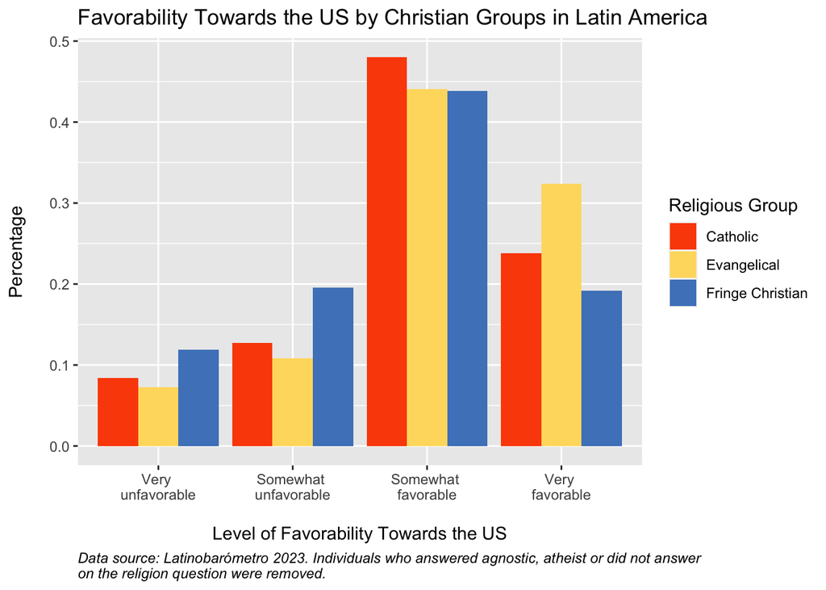

The regression tables show effects in terms of favorability towards the US (which range from 0 - 1). In my analysis, I describe the magnitude of the effects in units of standard deviation.

Individuals in Christian fringe religions were 0.22 standard deviations less favorable towards the US compared to Catholics and 0.38 standard deviations less favorable compared to Evangelicals. These effects were both significant.

This indicates that being in a Fringe Christian group lowers the probability that an individual will have a favorable opinion towards the US, opposing my hypothesis. This could be explained by other factors and the rest of this paper will attempt to answer why Fringe Christians are less favorable towards the US compared to Catholics and Evangelicals.

|  | Catholics | Evangelicals |
| --- | --- | --- |
| (Intercept) | 0.647 | 0.693 |
|  | p = <0.001 | p = <0.001 |
| christian_small | −0.065 | −0.111 |
|  | p = <0.001 | p = <0.001 |
| Num.Obs. | 9845 | 4456 |
| R2 | 0.001 | 0.007 |
| R2 Adj. | 0.001 | 0.007 |
| AIC | 3579.8 | 1667.1 |
| BIC | 3601.4 | 1686.3 |
| Log.Lik. | −1786.898 | −830.534 |
| F |  | 30.398 |
| RMSE | 0.29 | 0.29 |

## 5. Empirical Extension

The regression tables show effects in terms of favorability towards the US (which range from 0 - 1). In my analysis, I describe the magnitude of the effects in units of standard deviation.

#### Devotion

Fringe Christians are more likely to describe themselves as “Very devout” and “Devout” than Catholics and Evangelicals. This may be due to the nature of the religions themselves, as Mormonism, Jehovah’s Witnesses, and Adventists demand greater participation from its members, which in turn, may make members feel more devout than other mainstream Christian religions. Therefore, it is unlikely that Fringe Christian religions simply attract individuals with a high propensity for religious devotion.

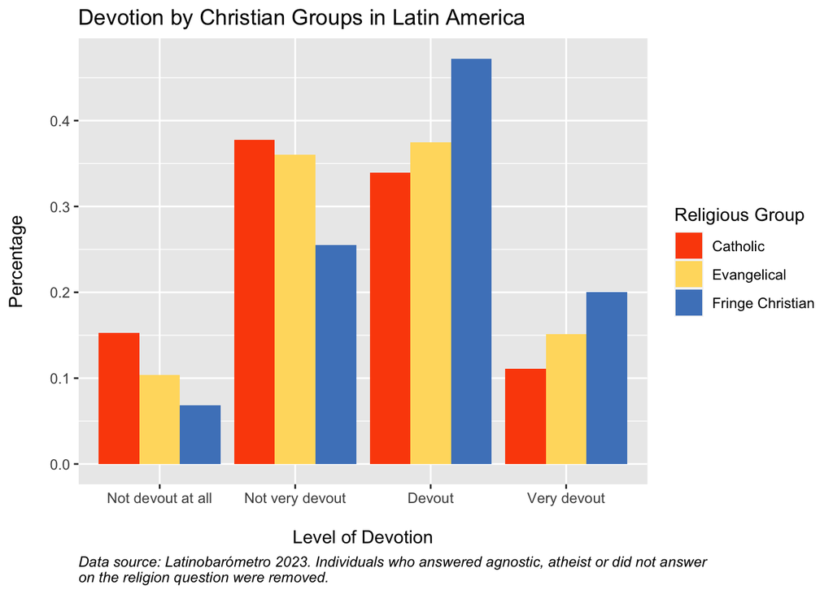

|  | Catholics | Evangelicals | Catholics, holding devotion constant | Evangelicals, holding devotion constant |
| --- | --- | --- | --- | --- |
| (Intercept) | 0.625 | 0.696 | 0.617 | 0.708 |
|  | p = <0.001 | p = <0.001 | p = <0.001 | p = <0.001 |
| christian_small | −0.014 | −0.085 | −0.073 | −0.110 |
|  | p = 0.765 | p = 0.069 | p = <0.001 | p = <0.001 |
| S1A | 0.051 | −0.006 |  |  |
|  | p = <0.001 | p = 0.692 |  |  |
| christian_small × S1A | −0.100 | −0.043 |  |  |
|  | p = 0.155 | p = 0.552 |  |  |
| factor(S1A)0.33 |  |  | 0.026 | −0.016 |
|  |  |  | p = 0.003 | p = 0.313 |
| factor(S1A)0.67 |  |  | 0.047 | −0.022 |
|  |  |  | p = <0.001 | p = 0.154 |
| factor(S1A)1 |  |  | 0.042 | −0.009 |
|  |  |  | p = <0.001 | p = 0.628 |
| Num.Obs. | 9675 | 4421 | 9675 | 4421 |
| R2 | 0.004 | 0.007 | 0.004 | 0.007 |
| R2 Adj. | 0.004 | 0.006 | 0.004 | 0.007 |
| AIC | 3430.1 | 1649.7 | 3428.2 | 1649.9 |
| BIC | 3466.0 | 1681.7 | 3471.2 | 1688.2 |
| Log.Lik. | −1710.064 | −819.868 | −1708.093 | −818.941 |
| RMSE | 0.29 | 0.29 | 0.29 | 0.29 |

#### Socioeconomic Status

When socioeconomic status is low, the average favorability score was 5.8 and 6.6 (on a scale of 0 - 10) among Catholics and Evangelicals. An increase in education was associated with an increase of 0.35 in favorability for Catholics and an increase of 0.18 in favorability for and Evangelicals. Compared to Catholics and Evangelicals, the favorability of Fringe Christians with low socioeconomic status decreased by 0.59 and 0.86, respectively. Compared to Evangelicals, increased socioeconomic status among Fringe Christians increased favorability by 0.81. This effect was not significant compared to Catholics. When controlling for socioeconomic status, the effect of being in a Fringe Christian religion was found to have a significant negative effect of 0.21 and 0.37, compared to Catholics and Evangelicals.

|  | Catholics | Evangelicals | Catholics, holding socioecon. status constant | Evangelicals, holding socioecon. status constant |
| --- | --- | --- | --- | --- |
| (Intercept) | 0.582 | 0.659 | 0.682 | 0.677 |
|  | p = <0.001 | p = <0.001 | p = <0.001 | p = <0.001 |
| christian_small | −0.174 | −0.250 | −0.060 | −0.107 |
|  | p = 0.005 | p = <0.001 | p = 0.002 | p = <0.001 |
| S24 | 0.103 | 0.052 |  |  |
|  | p = <0.001 | p = 0.011 |  |  |
| christian_small × S24 | 0.185 | 0.236 |  |  |
|  | p = 0.056 | p = 0.017 |  |  |
| factor(S24)0.25 |  |  | −0.083 | −0.012 |
|  |  |  | p = 0.004 | p = 0.790 |
| factor(S24)0.5 |  |  | −0.053 | −0.001 |
|  |  |  | p = 0.047 | p = 0.980 |
| factor(S24)0.75 |  |  | −0.023 | 0.033 |
|  |  |  | p = 0.393 | p = 0.447 |
| factor(S24)1 |  |  | 0.013 | 0.023 |
|  |  |  | p = 0.631 | p = 0.594 |
| Num.Obs. | 9845 | 4456 | 9845 | 4456 |
| R2 | 0.008 | 0.010 | 0.009 | 0.010 |
| R2 Adj. | 0.007 | 0.010 | 0.008 | 0.009 |
| AIC | 3520.7 | 1655.7 | 3510.9 | 1660.0 |
| BIC | 3556.6 | 1687.8 | 3561.3 | 1704.8 |
| Log.Lik. | −1755.329 | −822.873 | −1748.452 | −823.013 |
| F |  | 15.275 |  | 9.104 |
| RMSE | 0.29 | 0.29 | 0.29 | 0.29 |

#### Education

In my data, Fringe Christians, Catholics, and Evangelicals had a similar average level of education, indicating that self selection into a Fringe Christian group was not associated with education. The median member of all of these groups had some secondary education. When holding education level constant, the effect of being in a Fringe Christian religion decreased favorability by 0.23 and 0.36, compared to Catholics and Evangelicals. I aim to see whether favorability among Christian groups in Latin America is affected by education.

**Low Education:** For Catholics with low education, the average favorability towards US was 6.2 (on a scale from 0 - 10). Compared to Catholics, Fringe Christian individuals with a low education had a -0.6 decrease in favorability. Among Catholics, when education level increases within the low education group, there was a 0.02 increase in favorability. The difference in the effect of education level on Fringe Christian individuals compared to Catholics was not significant.

Compared to Evangelicals, Fringe Christians with low level of education experienced a 0.92 decrease in favorability. Among Evangelicals within the low education group, additional education level was associated with a 0.02 decrease in favorability. However, additional education had a positive effect of 0.12 on Fringe Christian individuals compared to Evangelicals.

**Medium Education:** For Catholic and Evangelical medium education respondents, an increase in education level did not significant affect favorability. Compared to Catholics and Evangelicals, Fringe Christian identity was found to decrease favorability by 3.65 and 3.77, respectively. Additional education did not significant effect favorability among Catholics and Evangelicals, but there was also a significant effect of additional education on Fringe Christian individuals compared to both groups, with a positive change of 0.72 for both comparisons.

**High Education:** Finally, for high education respondents, neither additional education nor religious group was found to significantly effect favorability towards the US.

|  | Catholic, Low Education | Evangelical, Low Education | Catholic, Medium Education | Evangelical, Medium Education | Catholic, High Education | Evangelical, High Education | Catholic, holding education constant | Evangelical, holding education constant |
| --- | --- | --- | --- | --- | --- | --- | --- | --- |
| (Intercept) | 0.623 | 0.718 | 0.612 | 0.647 | 0.742 | 0.793 | 0.653 | 0.707 |
|  | p = <0.001 | p = <0.001 | p = <0.001 | p = <0.001 | p = <0.001 | p = <0.001 | p = <0.001 | p = <0.001 |
| christian_small | −0.175 | −0.270 | −1.064 | −1.099 | 0.421 | 0.370 | −0.068 | −0.106 |
|  | p = 0.004 | p = <0.001 | p = <0.001 | p = <0.001 | p = 0.354 | p = 0.417 | p = <0.001 | p = <0.001 |
| REEEDUC.1 | 0.005 | −0.006 | 0.008 | 0.008 | −0.013 | −0.017 |  |  |
|  | p = 0.001 | p = 0.018 | p = 0.421 | p = 0.621 | p = 0.272 | p = 0.339 |  |  |
| christian_small × REEEDUC.1 | 0.023 | 0.035 | 0.209 | 0.210 | −0.068 | −0.063 |  |  |
|  | p = 0.057 | p = 0.005 | p = 0.001 | p = 0.002 | p = 0.325 | p = 0.361 |  |  |
| factor(REEEDUC.1)2 |  |  |  |  |  |  | −0.048 | −0.023 |
|  |  |  |  |  |  |  | p = 0.003 | p = 0.269 |
| factor(REEEDUC.1)3 |  |  |  |  |  |  | 0.004 | 0.013 |
|  |  |  |  |  |  |  | p = 0.824 | p = 0.489 |
| factor(REEEDUC.1)4 |  |  |  |  |  |  | −0.012 | −0.037 |
|  |  |  |  |  |  |  | p = 0.443 | p = 0.071 |
| factor(REEEDUC.1)5 |  |  |  |  |  |  | 0.001 | −0.018 |
|  |  |  |  |  |  |  | p = 0.971 | p = 0.317 |
| factor(REEEDUC.1)6 |  |  |  |  |  |  | 0.015 | −0.012 |
|  |  |  |  |  |  |  | p = 0.354 | p = 0.566 |
| factor(REEEDUC.1)7 |  |  |  |  |  |  | 0.001 | −0.033 |
|  |  |  |  |  |  |  | p = 0.968 | p = 0.118 |
| Num.Obs. | 9839 | 4453 | 4183 | 1739 | 2476 | 960 | 9839 | 4453 |
| R2 | 0.003 | 0.009 | 0.005 | 0.014 | 0.001 | 0.004 | 0.005 | 0.010 |
| R2 Adj. | 0.002 | 0.009 | 0.004 | 0.013 | 0.000 | 0.001 | 0.004 | 0.009 |
| AIC | 3567.7 | 1658.0 | 1308.4 | 616.3 | 674.5 | 231.1 | 3555.3 | 1662.0 |
| BIC | 3603.6 | 1690.0 | 1340.1 | 643.6 | 703.5 | 255.4 | 3620.0 | 1719.7 |
| Log.Lik. | −1778.829 | −823.982 | −649.186 | −303.152 | −332.235 | −110.528 | −1768.637 | −822.023 |
| F |  |  |  | 8.358 |  | 1.409 |  |  |
| RMSE | 0.29 | 0.29 | 0.28 | 0.29 | 0.28 | 0.27 | 0.29 | 0.29 |

These results suggest that among low education respondents, being in a Fringe Christian religion decreased favorability, compared to both Catholics and Evangelicals. An increase in education among low education respondents had a significant but small effect on Catholics and Evangelicals. For individuals in a Fringe Christian religion with low education, an increase in education increased favorability compared to Evangelicals. Among individuals with a medium education, an increase in education did not increase favorability for Catholics and Evangelicals. However, for those in a Fringe Christian religion with medium education, an increase in education did increase favorability. Individuals’ favorability towards of US in the high education group was not significantly affected by any of these variables.

Overall, low and medium education Fringe Christians had significantly lower favorability ratings, compared to low and medium education Catholics and Evangelicals. For individuals with a medium education and in a Fringe Christian religion, an increase in education increased favorability. This indicates that religion plays a significant role in favorability for people with a low and medium education. Additionally, additional education for an individual with medium education and in a Fringe Christian religion can significantly increase their favorability. For people with a high education however, the ability of additional education or religion to significantly affect one’s political beliefs was not significant.

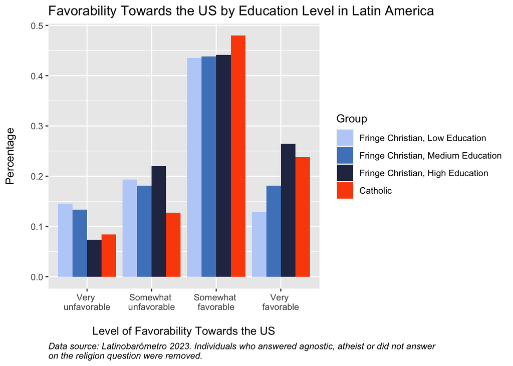

#### Country

National politics may also play a large role in how people view the US. By comparing favorability towards the US between individuals in Fringe Christian religions and mainstream Catholics and Evangelicals, we attempt to distinguish what role nationality plays alongside religion. In this analysis, six countries (Costa Rica, Rep. Dominicana, El Salvador, Guatemala, Honduras, and Panamá) were removed due to insufficient data.

The effects of nationality on favorability towards the US vary across Latin America. Average favorability towards the US was lowest in countries like Venezuela (5.4, on a scale from 0 - 10) and Bolivia (5.5) and highest in countries like Colombia (6.7) and Ecuador (7.2). In Venezuela and Mexico, there was a large difference between the national average favorability and the Fringe Christian average favorability. Meanwhile in Ecuador, there was not a large difference between the national average favorability and the Fringe Christian average favorability. The effect of country may vary depending on existing national attitudes.

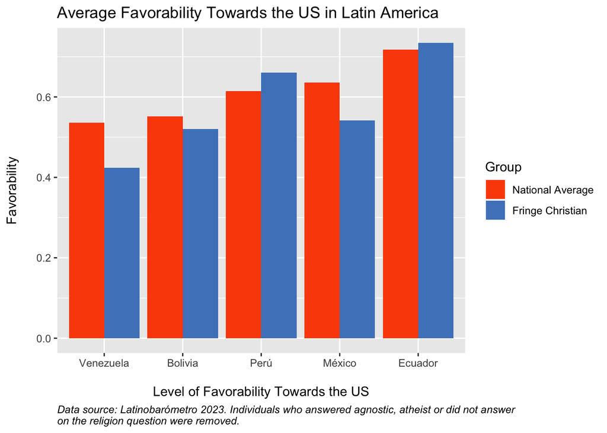

We see varied effects when looking at Venezuela (low national favorability), Peru (moderate national favorability), and Ecuador (high national favorability). **Venezuela:** Among Catholics, Venezuelan nationality by itself was associated with a 0.43 decrease in favorability and among Evangelicals, a 0.53 decrease. However, the effect of Venezuelan identity on Fringe Christian individuals was not found to significantly affect favorability, compared to Catholics or compared to Evangelicals.

|  | Catholics | Evangelicals |
| --- | --- | --- |
| (Intercept) | 0.655 | 0.705 |
|  | p = <0.001 | p = <0.001 |
| christian_small | −0.056 | −0.106 |
|  | p = 0.007 | p = <0.001 |
| venezuela | −0.124 | −0.154 |
|  | p = <0.001 | p = <0.001 |
| christian_small × venezuela | −0.051 | −0.021 |
|  | p = 0.440 | p = 0.756 |
| Num.Obs. | 9845 | 4456 |
| R2 | 0.012 | 0.028 |
| R2 Adj. | 0.012 | 0.027 |
| AIC | 3471.7 | 1576.6 |
| BIC | 3507.7 | 1608.6 |
| Log.Lik. | −1730.843 | −783.316 |
| F |  | 42.131 |
| RMSE | 0.29 | 0.29 |

**Peru:** For Catholics, Peruvian nationality by itself was found to decrease a respondent’s favorability by 0.13. Peruvian identity had a positive effect of 0.47 on favorability for Fringe Christians, compared to Catholics.

When comparing the effects of Peruvian nationality among Evangelicals and Fringe Christians, we see larger substantive effects. Peruvian identity by itself was found to decrease a respondent’s favorability by 0.31. However, Peruvian identity had a positive effect of 0.65 on Fringe Christian individuals, compared to Evangelicals.

|  | Catholics | Evangelicals |
| --- | --- | --- |
| (Intercept) | 0.650 | 0.697 |
|  | p = <0.001 | p = <0.001 |
| christian_small | −0.090 | −0.137 |
|  | p = <0.001 | p = <0.001 |
| peru | −0.037 | −0.090 |
|  | p = <0.001 | p = <0.001 |
| christian_small × peru | 0.137 | 0.191 |
|  | p = 0.005 | p = <0.001 |
| Num.Obs. | 9845 | 4456 |
| R2 | 0.003 | 0.012 |
| R2 Adj. | 0.002 | 0.011 |
| AIC | 3567.9 | 1647.1 |
| BIC | 3603.9 | 1679.1 |
| Log.Lik. | −1778.959 | −818.561 |
| F |  | 18.179 |
| RMSE | 0.29 | 0.29 |

**Ecuador:** Ecuadorean nationality had a significant positive effect of 0.29 on favorability among Catholics, but not among Evangelicals. Ecuadorean nationality did not have a significant effect on Fringe Christian individuals compared to Catholics. However, compared to Evangelicals, Ecuadorean nationality did have a positive effect of 0.54 on Fringe Christian individuals.

|  | Catholics | Evangelicals |
| --- | --- | --- |
| (Intercept) | 0.640 | 0.692 |
|  | p = <0.001 | p = <0.001 |
| christian_small | −0.082 | −0.134 |
|  | p = <0.001 | p = <0.001 |
| ecuador | 0.084 | 0.018 |
|  | p = <0.001 | p = 0.385 |
| christian_small × ecuador | 0.093 | 0.159 |
|  | p = 0.106 | p = 0.009 |
| Num.Obs. | 9845 | 4456 |
| R2 | 0.008 | 0.009 |
| R2 Adj. | 0.008 | 0.008 |
| AIC | 3513.0 | 1660.7 |
| BIC | 3548.9 | 1692.8 |
| Log.Lik. | −1751.485 | −825.371 |
| F |  | 13.595 |
| RMSE | 0.29 | 0.29 |

Depending on existing national attitudes, nationality may or may not significant effect favorability across Latin American countries. The interaction effect of country and religion was also not always found to be significant and varied in magnitude. In some countries, nationality and religion did significantly affect favorability, however in other countries, only one or neither variable was found to be significant. This indicates large variability across Latin American and prompts further research into how national attitudes differ across Latin America.

| Country | National Average (0 - 10) | Catholic National Average | Evangelical National Average | Fringe Christian National Average | Difference (National Average) | Difference (Catholic) | Difference (Evangelical) |
| --- | --- | --- | --- | --- | --- | --- | --- |
| Venezuela | 5.36 | 5.31 | 5.50 | 4.24 | -1.12 | -1.07 | -1.26 |
| Bolivia | 5.52 | 5.60 | 5.44 | 5.20 | -0.32 | -0.40 | -0.24 |
| Argentina | 5.62 | 5.65 | 5.15 | 3.35 | -2.27 | -2.30 | -1.80 |
| Uruguay | 5.90 | 6.04 | 5.78 | 5.01 | -0.89 | -1.03 | -0.77 |
| Paraguay | 6.04 | 6.05 | 6.11 | 6.67 | 0.64 | 0.63 | 0.56 |
| Perú | 6.14 | 6.13 | 6.07 | 6.61 | 0.46 | 0.47 | 0.54 |
| México | 6.36 | 6.44 | 6.48 | 5.42 | -0.94 | -1.02 | -1.06 |
| Brasil | 6.45 | 6.37 | 6.62 | 6.70 | 0.25 | 0.33 | 0.08 |
| Chile | 6.58 | 6.78 | 5.66 | 5.35 | -1.23 | -1.42 | -0.30 |
| Colombia | 6.72 | 6.74 | 6.75 | 6.07 | -0.65 | -0.67 | -0.68 |
| Ecuador | 7.18 | 7.24 | 7.10 | 7.35 | 0.17 | 0.11 | 0.25 |

## 6. Discussion and Policy Implications

Being in a Fringe Christian religion was found to decrease an individual’s favorability of the US, opposing my original hypothesis.

In my survey, Fringe Christians had a similar level of education compared to Catholics and Evangelicals, although they were more devoted than both groups. Devotion was found to increase favorability only for Catholics.

Existing research from Chile and Argentina found that more devout individuals tended to be more supportive of government institutions and democratic systems (Patterson 2004). In my analysis, I found that increased devotion among Catholics increased their favorbility towards the US. However, this effect did not occur among Evangelicals or Fringe Christians.

The same study also found that political engagement mattered more than religiosity or demographics in explaining support for democratic beliefs. Individuals with increased political engagement were more likely to support democratic attitudes, while those that were less politically engaged were more likely to settle for the status quo and have less faith in the government (Patterson 2004). However, using the “How interested are you in politics?” question, I did not find these effects to be significant in my analysis.

In my analysis, among those with low socioeconomic status, Fringe Christians had lower opinions of the US than Catholics and Evangelicals, and increased socioeconomic did increase favorability compared to Evangelicals. However, the socioeconomic status of all three groups were similar, so this variable does not help explain why Fringe Christians have a lower favorability.

In the US, increased education was found to increase religious attendance at the individual level, but decrease religious beliefs (Glaeser and Sacerdote 2008). In Canada, researchers found that higher levels of education led to lower levels of religious affiliation later in life (Hungerman 2014). In my analysis, the beliefs of respondents with some university education were not significantly affected by either an increase in education or joining a Fringe Christian religion. Therefore, my results are challenging to explain.

Holding constant education, devotion, and socioeconomic status, being in a Fringe Christian was still found to have a negative effect on favorability.

Favorability towards the US varies widely across Latin America. One of the strongest predictors of favorability in Latin America is distance from the US, meaning the individuals in Central America are more favorable than individuals in South America. The next most important factor is receiving money from US emigrants (2016). This shows that proximity and perceived economic benefit play a large role in favorability of the US.

My analysis would benefit from focusing on specific countries and exploring whether proximity from the US also affects religiosity. However, Fringe Christian data is missing or insufficient in many countries, so this kind of analysis was not possible. Looking at Latin American countries together might not be effective to find trends in religiosity and political beliefs.

In regards to policymaking, this analysis shows that religion continues to influence opinions and people of different religions also may have significantly different beliefs. Although most religious institutions and religious leaders do not explicitly espouse political ideals, the mindset and actions that religions promote have the potential to permeate through all aspects of one’s life. Policymakers should be mindful of the religious makeup and religious devotion of constituents when making decisions.

## Bibliography

2016. *The Economist*. The Economist Newspaper. https://www.economist.com/the-americas/2016/03/19/dugout-diplomacy.

———. 2023. *Jehovah’s Witnesses*. https://www.jw.org/en/library/books/2023-Service-Year-Report-of-Jehovahs-Witnesses-Worldwide/2023-Country-and-Territory-Reports/.

———. 2024. Britannica. https://www.britannica.com/topic/Jehovahs-Witnesses.

Alston, Jon P, and Benigno E Aguirre. 1979. “Congregational Size and the Decline of Sectarian Commitment: The Case of the Jehovah’s Witnesses in South and North America.” *Sociological Analysis* 40 (1): 63–70.

Ayala, Leonor. 2004. “Mormon Conversions Surge in Latin America.” *NBCNews.com*. NBCUniversal News Group. https://www.nbcnews.com/id/wbna5378318.

Gill, Anthony. 1998. *Rendering Unto Caesar: The Catholic Church and the State in Latin America*. University of Chicago Press.

Glaeser, Edward L, and Bruce I Sacerdote. 2008. “Education and Religion.” *Journal of Human Capital* 2 (2): 188–215.

Holdorf, Ruben Dargã. 2021. “ESDA | South American Division.” *Encyclopedia of Seventh-Day Adventists*. https://encyclopedia.adventist.org/article?id=1IFC.

Hungerman, Daniel M. 2014. “The Effect of Education on Religion: Evidence from Compulsory Schooling Laws.” *Journal of Economic Behavior & Organization* 104: 52–63.

Jelen, Ted Gerard, and Clyde Wilcox. 2002. *Religion and Politics in Comparative Perspective: The One, the Few, and the Many*. Cambridge University Press.

Knowlton, David C. 1996. “Mormonism in Latin America: Towards the Twenty-First Century.” *Dialogue: A Journal of Mormon Thought* 29 (1): 159–76.

Larsen, Andy. 2022. “Andy Larsen: What Issues Do Utahns Support Most - That Our Lawmakers Have Ignored?” *The Salt Lake Tribune*. https://www.sltrib.com/news/2022/08/23/andy-larsen-what-issues-do/.

Lipka, Michael. 2014. “7 Key Takeaways about Religion in Latin America.” *Pew Research Center*. Pew Research Center. https://www.pewresearch.org/short-reads/2014/11/13/7-key-takeaways-about-religion-in-latin-america/.

———. 2015. “A Closer Look at Seventh-Day Adventists in America.” *Pew Research Center*. Pew Research Center. https://www.pewresearch.org/short-reads/2015/11/03/a-closer-look-at-seventh-day-adventists-in-america/.

———. 2016. “A Closer Look at Jehovah’s Witnesses Living in the u.s.” *Pew Research Center*. Pew Research Center. https://www.pewresearch.org/short-reads/2016/04/26/a-closer-look-at-jehovahs-witnesses-living-in-the-u-s/.

Patterson, Eric. 2004. “Different Religions, Different Politics? Religion and Political Attitudes in Argentina and Chile.” *Journal for the Scientific Study of Religion* 43 (3): 345–62.

Phillips, Glenn, and Israel Leito. 2020. “Inter-American Division.” *Encyclopedia of Seventh-Day Adventists*. https://encyclopedia.adventist.org/article?id=EI7C.

Steigenga, Timothy J, and Edward L Cleary. 2007. *Conversion of a Continent: Contemporary Religious Change in Latin America*. Rutgers University Press.